# Lab 2 Part 2 Modèle de survie

Devoir maison obligatoire (Dauphine)

Alexandre Marette

8 décembre 2019

# Exercise 8.11 of Klein and Moeschberger 2005

Nous nous intéressons au jeu de données pneumonia, provenant du package KMsurv.

We study data gathered from annual personal interviews conducted for the National Longitudinal Survey of Youth (NLSY) from 1979 through 1986. This data was used to study whether or not the mother’s feeding choice protected the infant against hospitalized pneumonia in the first year of life. Ages of young children at the time they were hospitalized with pneumonia were recorded as well as the observed ages of those infants that were not hospitalized with pneumonia during the study period. The datapneumon is available in R package KMsurv. Use the discrete method for handling ties in the following.

## **Question 1 :** Check if the variables have been correcly imported, especially the factors

### **1.1 Description des données**

============================================================

The pneumon data frame has 3470 rows and 15 columns.

**1. chldage** – *integer*  
Age child had pneumonia, months

**2. hospital** – *categorial*  
Indicator for hospitalization for pneumonia (1=yes, 0=no)

**3. mthage** –*integer* Age of the mother, years

**4. urban** –*categorial* Urban environment for mother (1=yes, 0=no)

**7. region** –*categorial* Region of the coutry (1=northeast, 2=north central, 3=south, 4=west)

**8. poverty** –*categorial* Mother at poverty level (1=yes, 0=no)

**9. bweight** –*categorial* Normal birthweight (>5.5 lbs.) (1=yes, 0=no)

**10. race** –*categorial* Race of the mother (1=white, 2=black, 3=other)

**11. education** –*integer* Education of the mother, years of school

**12. nsibs** –*integer* Number of siblings of the child

**13. wmonth** –*integer* Month the child was weaned

**14. sfmonth** –*integer* Month the child on solid food

**15. agepn** –*integer* Age child in the hospital for pneumonia, months

**Source** Klein and Moeschberger (1997) Survival Analysis Techniques for Censored and truncated data, Springer. National Longitudinal Survey of Youth Handbook The Ohio State University, 1995.

============================================================

### **1.2 Lecture des données et premières explorations**

```r
#load library
library(fitdistrplus)
library(asaur)
library(tidyverse)
library(lubridate)
library(KMsurv)
library(ggfortify)
library(survival)
library(MASS)
```

```r
#import et exploration des données
data("pneumon")
d_pneumon=pneumon
summary(d_pneumon)
```

```
##     chldage          hospital           mthage          urban
##  Min.   : 0.500   Min.   :0.00000   Min.   :14.00   Min.   :0.0000
##  1st Qu.: 8.000   1st Qu.:0.00000   1st Qu.:20.00   1st Qu.:1.0000
##  Median :12.000   Median :0.00000   Median :22.00   Median :1.0000
##  Mean   : 9.845   Mean   :0.02104   Mean   :21.64   Mean   :0.7605
##  3rd Qu.:12.000   3rd Qu.:0.00000   3rd Qu.:23.00   3rd Qu.:1.0000
##  Max.   :12.000   Max.   :1.00000   Max.   :29.00   Max.   :1.0000
##     alcohol           smoke            region        poverty
##  Min.   :0.0000   Min.   :0.0000   Min.   :1.00   Min.   :0.0000
##  1st Qu.:0.0000   1st Qu.:0.0000   1st Qu.:2.00   1st Qu.:1.0000
##  Median :0.0000   Median :0.0000   Median :3.00   Median :1.0000
##  Mean   :0.6646   Mean   :0.4415   Mean   :2.65   Mean   :0.9222
##  3rd Qu.:1.0000   3rd Qu.:1.0000   3rd Qu.:3.00   3rd Qu.:1.0000
##  Max.   :4.0000   Max.   :2.0000   Max.   :4.00   Max.   :1.0000
##     bweight            race        education         nsibs
##  Min.   :0.0000   Min.   :1.00   Min.   : 0.00   Min.   :0.0000
##  1st Qu.:0.0000   1st Qu.:1.00   1st Qu.:10.00   1st Qu.:0.0000
##  Median :0.0000   Median :1.00   Median :12.00   Median :0.0000
##  Mean   :0.3597   Mean   :1.61   Mean   :11.44   Mean   :0.6775
##  3rd Qu.:1.0000   3rd Qu.:2.00   3rd Qu.:12.00   3rd Qu.:1.0000
##  Max.   :1.0000   Max.   :3.00   Max.   :19.00   Max.   :6.0000
##      wmonth          sfmonth           agepn
##  Min.   : 0.000   Min.   : 0.000   Min.   : 0.000
##  1st Qu.: 0.000   1st Qu.: 0.000   1st Qu.: 3.000
##  Median : 0.000   Median : 0.000   Median :10.000
##  Mean   : 1.926   Mean   : 1.121   Mean   : 7.865
##  3rd Qu.: 2.000   3rd Qu.: 1.000   3rd Qu.:12.000
##  Max.   :28.000   Max.   :18.000   Max.   :12.000
```

```r
glimpse(d_pneumon)
```

```
## Observations: 3,470
## Variables: 15
## $ chldage   <dbl> 12.0, 12.0, 3.0, 2.0, 4.0, 12.0, 7.0, 3.0, 7.0, 12.0, 12.0,…
## $ hospital  <int> 0, 0, 0, 0, 0, 0, 0, 0, 0, 0, 0, 0, 0, 0, 0, 0, 0, 0, 0, 0,…
## $ mthage    <int> 22, 20, 24, 22, 21, 20, 24, 24, 26, 21, 24, 27, 20, 25, 19,…
## $ urban     <int> 1, 1, 1, 1, 1, 1, 1, 1, 1, 1, 1, 1, 1, 1, 1, 1, 1, 1, 0, 1,…
## $ alcohol   <int> 0, 1, 3, 2, 1, 0, 0, 3, 2, 1, 0, 0, 0, 2, 0, 4, 0, 2, 1, 1,…
## $ smoke     <int> 0, 0, 0, 2, 2, 0, 0, 0, 2, 0, 0, 0, 0, 0, 1, 1, 1, 0, 0, 1,…
## $ region    <int> 1, 1, 1, 1, 1, 1, 1, 1, 1, 1, 1, 1, 1, 1, 1, 1, 1, 1, 1, 1,…
## $ poverty   <int> 1, 1, 1, 1, 1, 1, 1, 1, 1, 1, 1, 1, 1, 1, 1, 1, 1, 1, 1, 1,…
## $ bweight   <int> 1, 0, 0, 0, 1, 0, 0, 0, 0, 0, 0, 0, 1, 0, 1, 0, 0, 0, 0, 1,…
## $ race      <int> 1, 1, 1, 1, 1, 1, 1, 1, 1, 1, 1, 1, 1, 1, 1, 1, 1, 1, 1, 1,…
## $ education <int> 10, 12, 12, 9, 12, 12, 12, 14, 12, 12, 16, 16, 12, 12, 11, …
## $ nsibs     <int> 1, 1, 2, 0, 0, 0, 1, 0, 0, 0, 0, 1, 0, 0, 0, 0, 0, 1, 0, 0,…
## $ wmonth    <int> 1, 2, 1, 0, 0, 0, 0, 4, 1, 3, 0, 0, 0, 4, 0, 1, 9, 10, 9, 4…
## $ sfmonth   <int> 1, 2, 0, 0, 0, 0, 0, 2, 1, 2, 0, 0, 0, 2, 0, 1, 2, 3, 9, 3,…
## $ agepn     <int> 1, 12, 3, 2, 4, 12, 7, 3, 6, 12, 12, 12, 3, 4, 2, 4, 10, 3,…
```

### **1.3 Correction et modification du jeu de données**

```r
#Suppression de la variable "agepn"
d_pneumon$agepn=NULL

#Modification du type de la variable "chldage", de float à integer
d_pneumon$chldage=as.integer(d_pneumon$chldage)

#transformation des variables categorielles de type integer en type factor
d_pneumon$urban=as.factor(d_pneumon$urban)
d_pneumon$alcohol=as.factor(d_pneumon$alcohol)
d_pneumon$smoke=as.factor(d_pneumon$smoke)
d_pneumon$region=as.factor(d_pneumon$region)
d_pneumon$poverty=as.factor(d_pneumon$poverty)
d_pneumon$bweight=as.factor(d_pneumon$bweight)
d_pneumon$race=as.factor(d_pneumon$race)

glimpse(d_pneumon)
```

```
## Observations: 3,470
## Variables: 14
## $ chldage   <int> 12, 12, 3, 2, 4, 12, 7, 3, 7, 12, 12, 12, 3, 4, 12, 8, 10, …
## $ hospital  <int> 0, 0, 0, 0, 0, 0, 0, 0, 0, 0, 0, 0, 0, 0, 0, 0, 0, 0, 0, 0,…
## $ mthage    <int> 22, 20, 24, 22, 21, 20, 24, 24, 26, 21, 24, 27, 20, 25, 19,…
## $ urban     <fct> 1, 1, 1, 1, 1, 1, 1, 1, 1, 1, 1, 1, 1, 1, 1, 1, 1, 1, 0, 1,…
## $ alcohol   <fct> 0, 1, 3, 2, 1, 0, 0, 3, 2, 1, 0, 0, 0, 2, 0, 4, 0, 2, 1, 1,…
## $ smoke     <fct> 0, 0, 0, 2, 2, 0, 0, 0, 2, 0, 0, 0, 0, 0, 1, 1, 1, 0, 0, 1,…
## $ region    <fct> 1, 1, 1, 1, 1, 1, 1, 1, 1, 1, 1, 1, 1, 1, 1, 1, 1, 1, 1, 1,…
## $ poverty   <fct> 1, 1, 1, 1, 1, 1, 1, 1, 1, 1, 1, 1, 1, 1, 1, 1, 1, 1, 1, 1,…
## $ bweight   <fct> 1, 0, 0, 0, 1, 0, 0, 0, 0, 0, 0, 0, 1, 0, 1, 0, 0, 0, 0, 1,…
## $ race      <fct> 1, 1, 1, 1, 1, 1, 1, 1, 1, 1, 1, 1, 1, 1, 1, 1, 1, 1, 1, 1,…
## $ education <int> 10, 12, 12, 9, 12, 12, 12, 14, 12, 12, 16, 16, 12, 12, 11, …
## $ nsibs     <int> 1, 1, 2, 0, 0, 0, 1, 0, 0, 0, 0, 1, 0, 0, 0, 0, 0, 1, 0, 0,…
## $ wmonth    <int> 1, 2, 1, 0, 0, 0, 0, 4, 1, 3, 0, 0, 0, 4, 0, 1, 9, 10, 9, 4…
## $ sfmonth   <int> 1, 2, 0, 0, 0, 0, 0, 2, 1, 2, 0, 0, 0, 2, 0, 1, 2, 3, 9, 3,…
```

Les données contiennent maintenant un temps censuré (chldage), une indicatrice de censure (hospital) et 12 variables explicatives.

## **Question 2 :**

Plot the Kaplan-Meier estimator for the survival function of the age at pneumonia. Give an estimation and a confidence interval for the probability for a newborn of not having developed pneumonia at 6 months.

```r
#Kaplan Meier estimator
var_surv=Surv(d_pneumon$chldage,d_pneumon$hospital)
KM_estimator = survfit(var_surv~1, data = d_pneumon)
```

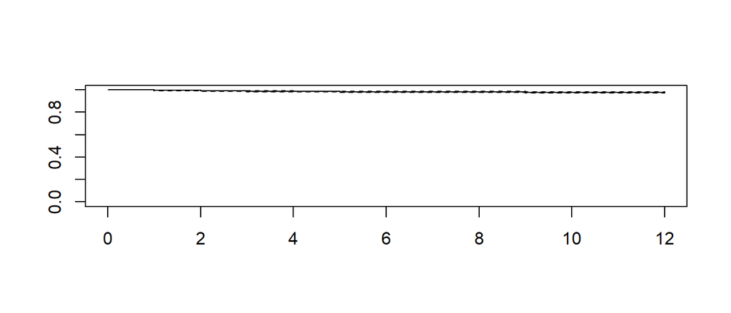

```r
plot(var_surv)
```

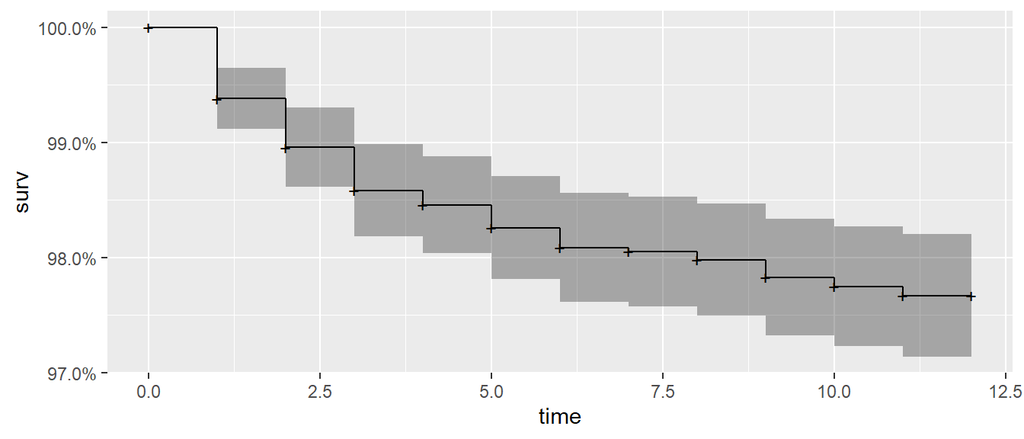

```r
autoplot(KM_estimator)
```

```r
summary(KM_estimator)
```

```
## Call: survfit(formula = var_surv ~ 1, data = d_pneumon)
##
##  time n.risk n.event survival std.err lower 95% CI upper 95% CI
##     1   3386      21    0.994 0.00135        0.991        0.996
##     2   3282      14    0.990 0.00176        0.986        0.993
##     3   3184      12    0.986 0.00205        0.982        0.990
##     4   3089       4    0.985 0.00215        0.980        0.989
##     5   2993       6    0.983 0.00229        0.978        0.987
##     6   2880       5    0.981 0.00241        0.976        0.986
##     7   2779       1    0.981 0.00243        0.976        0.985
##     8   2682       2    0.980 0.00249        0.975        0.985
##     9   2585       4    0.978 0.00260        0.973        0.983
##    10   2496       2    0.977 0.00265        0.972        0.983
##    11   2418       2    0.977 0.00271        0.971        0.982
```

La probabilité à 6 mois de ne pas développer une pneumonie est de 0,981 avec un intervalle de confiance à 95% compris entre 0,976 et 0,986.

## **Question 3 :**

Construct a dummy variable Z= 1 if infants were breast fed at birth, 0 if infants were never breast fed,and test the hypothesis H0: there is not difference in distributions of age at first pneumonia between child whether were breast fed or not.

```r
#Construction de la dummy variable Z :
d_pneumon$Z=ifelse(d_pneumon$wmonth > 0, 1,0)
d_pneumon$Z=as.integer(d_pneumon$Z)
str(d_pneumon)
```

```
## 'data.frame':    3470 obs. of  15 variables:
##  $ chldage  : int  12 12 3 2 4 12 7 3 7 12 ...
##  $ hospital : int  0 0 0 0 0 0 0 0 0 0 ...
##  $ mthage   : int  22 20 24 22 21 20 24 24 26 21 ...
##  $ urban    : Factor w/ 2 levels "0","1": 2 2 2 2 2 2 2 2 2 2 ...
##  $ alcohol  : Factor w/ 5 levels "0","1","2","3",..: 1 2 4 3 2 1 1 4 3 2 ...
##  $ smoke    : Factor w/ 3 levels "0","1","2": 1 1 1 3 3 1 1 1 3 1 ...
##  $ region   : Factor w/ 4 levels "1","2","3","4": 1 1 1 1 1 1 1 1 1 1 ...
##  $ poverty  : Factor w/ 2 levels "0","1": 2 2 2 2 2 2 2 2 2 2 ...
##  $ bweight  : Factor w/ 2 levels "0","1": 2 1 1 1 2 1 1 1 1 1 ...
##  $ race     : Factor w/ 3 levels "1","2","3": 1 1 1 1 1 1 1 1 1 1 ...
##  $ education: int  10 12 12 9 12 12 12 14 12 12 ...
##  $ nsibs    : int  1 1 2 0 0 0 1 0 0 0 ...
##  $ wmonth   : int  1 2 1 0 0 0 0 4 1 3 ...
##  $ sfmonth  : int  1 2 0 0 0 0 0 2 1 2 ...
##  $ Z        : int  1 1 1 0 0 0 0 1 1 1 ...
```

```r
#Test de l'hypothèse H0 : Il s'agit d'un test du Chi 2
Test_H_0 = survdiff(Surv(chldage,hospital)~Z, data = d_pneumon)
print(Test_H_0)
```

```
## Call:
## survdiff(formula = Surv(chldage, hospital) ~ Z, data = d_pneumon)
##
##        N Observed Expected (O-E)^2/E (O-E)^2/V
## Z=0 2036       59     42.7      6.22        15
## Z=1 1434       14     30.3      8.77        15
##
##  Chisq= 15  on 1 degrees of freedom, p= 1e-04
```

La p-value est très inférieur à 5% (p-value = 0,0001), on rejette donc l’hypothèse nulle H0.

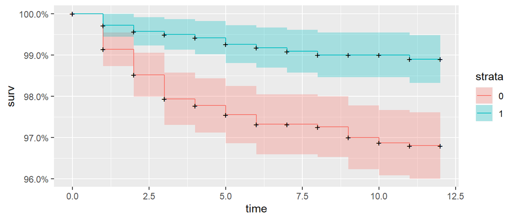

```r
#avec l'estimateur de Kaplan Meier
KM_estimator_2 = survfit(Surv(chldage,hospital)~Z, data = d_pneumon)

#Graphique de la variable
autoplot(KM_estimator_2)
```

```r
summary(KM_estimator_2)
```

```
## Call: survfit(formula = Surv(chldage, hospital) ~ Z, data = d_pneumon)
##
##                 Z=0
##  time n.risk n.event survival std.err lower 95% CI upper 95% CI
##     1   1975      17    0.991 0.00208        0.987        0.995
##     2   1920      12    0.985 0.00273        0.980        0.991
##     3   1856      11    0.979 0.00323        0.973        0.986
##     4   1803       3    0.978 0.00336        0.971        0.984
##     5   1750       4    0.975 0.00353        0.969        0.982
##     6   1687       4    0.973 0.00371        0.966        0.980
##     8   1580       1    0.973 0.00376        0.965        0.980
##     9   1526       4    0.970 0.00396        0.962        0.978
##    10   1478       2    0.969 0.00406        0.961        0.977
##    11   1436       1    0.968 0.00411        0.960        0.976
##
##                 Z=1
##  time n.risk n.event survival std.err lower 95% CI upper 95% CI
##     1   1411       4    0.997 0.00142        0.994        1.000
##     2   1362       2    0.996 0.00175        0.992        0.999
##     3   1328       1    0.995 0.00190        0.991        0.999
##     4   1286       1    0.994 0.00205        0.990        0.998
##     5   1243       2    0.993 0.00234        0.988        0.997
##     6   1193       1    0.992 0.00248        0.987        0.997
##     7   1148       1    0.991 0.00263        0.986        0.996
##     8   1102       1    0.990 0.00277        0.985        0.995
##    11    982       1    0.989 0.00295        0.983        0.995
```

Le graphique et le tableau résultat de l’estimation de Kaplan Meier de la fonction de survie des 2 cas (cas où l’enfant a bénéficié de l’allaitement maternel et cas où il n’en a pas bénéficié) montre qu’il y a bien une différence sensible entre les 2 fonctions de survie, ce, d’autant plus, que les intervalles de confiance ne se recouvrent plus dès le 2ème mois.

## **Question 4 :**

Test the hypothesis H0: β x breastf= 0, i.e., the survival functions for the two types of breast feeding are equal, using the likelihood ratio, and Wald tests. Find the estimate of β x breastf, its standard error, and the relative risk.

```r
fit_Z=coxph(Surv(chldage,hospital)~ Z, data = d_pneumon)
summary(fit_Z)
```

```
## Call:
## coxph(formula = Surv(chldage, hospital) ~ Z, data = d_pneumon)
##
##   n= 3470, number of events= 73
##
##      coef exp(coef) se(coef)     z Pr(>|z|)
## Z -1.0970    0.3339   0.2973 -3.69 0.000224 ***
## ---
## Signif. codes:  0 '***' 0.001 '**' 0.01 '*' 0.05 '.' 0.1 ' ' 1
##
##   exp(coef) exp(-coef) lower .95 upper .95
## Z    0.3339      2.995    0.1864    0.5979
##
## Concordance= 0.614  (se = 0.023 )
## Likelihood ratio test= 16.59  on 1 df,   p=5e-05
## Wald test            = 13.62  on 1 df,   p=2e-04
## Score (logrank) test = 15.04  on 1 df,   p=1e-04
```

## **Question 5 :**

Test the hypothesis that the times to hospitalized pneumonia are the same for the two feeding groups adjusting for each of these factors in a separate model using the Wald test.

Also available in the data set is information on other factors that may be associated with the timing of hospitalized pneumonia.  
These factors are age of the mother at the infant’s birth, rural-urban environment of the mother, use of alcohol by the mother (no drinks, less than one drink, 1-2 drinks,3-4 drinks, or more than 4 drinks per month), mother’s cigarette use (none, less than 1 pack/day, 1 or more pack/day), region of country (north east, north central, south, or west), birthweight of infant(less the 5.5 lbs or 5.5 lbs or more), poverty status of mother (yes/no), race of mother (white, black, or other), or number of siblings of infant.

```r
fit_mthage=coxph(Surv(chldage,hospital)~  mthage + Z, data = d_pneumon)
summary(fit_mthage)
```

```
## Call:
## coxph(formula = Surv(chldage, hospital) ~ mthage + Z, data = d_pneumon)
##
##   n= 3470, number of events= 73
##
##            coef exp(coef) se(coef)      z Pr(>|z|)
## mthage -0.06776   0.93448  0.04521 -1.499 0.133908
## Z      -1.02651   0.35826  0.30096 -3.411 0.000648 ***
## ---
## Signif. codes:  0 '***' 0.001 '**' 0.01 '*' 0.05 '.' 0.1 ' ' 1
##
##        exp(coef) exp(-coef) lower .95 upper .95
## mthage    0.9345      1.070    0.8552    1.0211
## Z         0.3583      2.791    0.1986    0.6462
##
## Concordance= 0.635  (se = 0.028 )
## Likelihood ratio test= 18.86  on 2 df,   p=8e-05
## Wald test            = 15.86  on 2 df,   p=4e-04
## Score (logrank) test = 17.29  on 2 df,   p=2e-04
```

```r
fit_urban=coxph(Surv(chldage,hospital)~  urban + Z, data = d_pneumon)
summary(fit_urban)
```

```
## Call:
## coxph(formula = Surv(chldage, hospital) ~ urban + Z, data = d_pneumon)
##
##   n= 3470, number of events= 73
##
##           coef exp(coef) se(coef)     z Pr(>|z|)
## urban1 -0.3819    0.6826   0.2496 -1.53 0.125997
## Z      -1.0720    0.3423   0.2978 -3.60 0.000319 ***
## ---
## Signif. codes:  0 '***' 0.001 '**' 0.01 '*' 0.05 '.' 0.1 ' ' 1
##
##        exp(coef) exp(-coef) lower .95 upper .95
## urban1    0.6826      1.465    0.4185    1.1133
## Z         0.3423      2.921    0.1910    0.6137
##
## Concordance= 0.638  (se = 0.029 )
## Likelihood ratio test= 18.82  on 2 df,   p=8e-05
## Wald test            = 16.01  on 2 df,   p=3e-04
## Score (logrank) test = 17.5  on 2 df,   p=2e-04
```

```r
fit_alcoh=coxph(Surv(chldage,hospital)~  alcohol + Z, data = d_pneumon)
summary(fit_alcoh)
```

```
## Call:
## coxph(formula = Surv(chldage, hospital) ~ alcohol + Z, data = d_pneumon)
##
##   n= 3470, number of events= 73
##
##             coef exp(coef) se(coef)      z Pr(>|z|)
## alcohol1  0.2079    1.2311   0.3051  0.681 0.495597
## alcohol2 -0.1742    0.8402   0.4703 -0.370 0.711160
## alcohol3 -0.2152    0.8064   0.5952 -0.361 0.717729
## alcohol4 -0.0404    0.9604   0.5952 -0.068 0.945879
## Z        -1.1108    0.3293   0.2989 -3.717 0.000202 ***
## ---
## Signif. codes:  0 '***' 0.001 '**' 0.01 '*' 0.05 '.' 0.1 ' ' 1
##
##          exp(coef) exp(-coef) lower .95 upper .95
## alcohol1    1.2311     0.8123    0.6770    2.2386
## alcohol2    0.8402     1.1903    0.3342    2.1121
## alcohol3    0.8064     1.2401    0.2512    2.5893
## alcohol4    0.9604     1.0412    0.2991    3.0839
## Z           0.3293     3.0367    0.1833    0.5915
##
## Concordance= 0.629  (se = 0.029 )
## Likelihood ratio test= 17.45  on 5 df,   p=0.004
## Wald test            = 14.44  on 5 df,   p=0.01
## Score (logrank) test = 15.85  on 5 df,   p=0.007
```

```r
fit_smoke=coxph(Surv(chldage,hospital)~  smoke + Z, data = d_pneumon)
summary(fit_smoke)
```

```
## Call:
## coxph(formula = Surv(chldage, hospital) ~ smoke + Z, data = d_pneumon)
##
##   n= 3470, number of events= 73
##
##           coef exp(coef) se(coef)      z Pr(>|z|)
## smoke1  0.7644    2.1476   0.2554  2.993 0.002760 **
## smoke2  0.6821    1.9781   0.3474  1.963 0.049609 *
## Z      -1.0514    0.3494   0.2978 -3.530 0.000415 ***
## ---
## Signif. codes:  0 '***' 0.001 '**' 0.01 '*' 0.05 '.' 0.1 ' ' 1
##
##        exp(coef) exp(-coef) lower .95 upper .95
## smoke1    2.1476     0.4656    1.3020    3.5426
## smoke2    1.9781     0.5055    1.0012    3.9084
## Z         0.3494     2.8617    0.1949    0.6264
##
## Concordance= 0.667  (se = 0.031 )
## Likelihood ratio test= 26.52  on 3 df,   p=7e-06
## Wald test            = 23.65  on 3 df,   p=3e-05
## Score (logrank) test = 25.69  on 3 df,   p=1e-05
```

```r
fit_region=coxph(Surv(chldage,hospital)~  region + Z, data = d_pneumon)
summary(fit_region)
```

```
## Call:
## coxph(formula = Surv(chldage, hospital) ~ region + Z, data = d_pneumon)
##
##   n= 3470, number of events= 73
##
##            coef exp(coef) se(coef)      z Pr(>|z|)
## region2  0.1651    1.1795   0.3420  0.483 0.629197
## region3 -0.3849    0.6805   0.3401 -1.132 0.257744
## region4 -0.4401    0.6440   0.4367 -1.008 0.313572
## Z       -1.0937    0.3350   0.3020 -3.621 0.000293 ***
## ---
## Signif. codes:  0 '***' 0.001 '**' 0.01 '*' 0.05 '.' 0.1 ' ' 1
##
##         exp(coef) exp(-coef) lower .95 upper .95
## region2    1.1795     0.8478    0.6034    2.3057
## region3    0.6805     1.4695    0.3494    1.3254
## region4    0.6440     1.5529    0.2736    1.5157
## Z          0.3350     2.9852    0.1853    0.6055
##
## Concordance= 0.649  (se = 0.029 )
## Likelihood ratio test= 21.47  on 4 df,   p=3e-04
## Wald test            = 18.5  on 4 df,   p=0.001
## Score (logrank) test = 20.07  on 4 df,   p=5e-04
```

```r
fit_poverty=coxph(Surv(chldage,hospital)~  poverty + Z, data = d_pneumon)
summary(fit_poverty)
```

```
## Call:
## coxph(formula = Surv(chldage, hospital) ~ poverty + Z, data = d_pneumon)
##
##   n= 3470, number of events= 73
##
##             coef exp(coef) se(coef)      z Pr(>|z|)
## poverty1 -0.1331    0.8753   0.3981 -0.334 0.738039
## Z        -1.0919    0.3356   0.2977 -3.668 0.000245 ***
## ---
## Signif. codes:  0 '***' 0.001 '**' 0.01 '*' 0.05 '.' 0.1 ' ' 1
##
##          exp(coef) exp(-coef) lower .95 upper .95
## poverty1    0.8753      1.142    0.4012    1.9100
## Z           0.3356      2.980    0.1872    0.6015
##
## Concordance= 0.616  (se = 0.024 )
## Likelihood ratio test= 16.69  on 2 df,   p=2e-04
## Wald test            = 13.73  on 2 df,   p=0.001
## Score (logrank) test = 15.16  on 2 df,   p=5e-04
```

```r
fit_bwght=coxph(Surv(chldage,hospital)~  bweight + Z, data = d_pneumon)
summary(fit_bwght)
```

```
## Call:
## coxph(formula = Surv(chldage, hospital) ~ bweight + Z, data = d_pneumon)
##
##   n= 3470, number of events= 73
##
##             coef exp(coef) se(coef)      z Pr(>|z|)
## bweight1  0.4203    1.5224   0.2376  1.768  0.07698 .
## Z        -1.0087    0.3647   0.3018 -3.342  0.00083 ***
## ---
## Signif. codes:  0 '***' 0.001 '**' 0.01 '*' 0.05 '.' 0.1 ' ' 1
##
##          exp(coef) exp(-coef) lower .95 upper .95
## bweight1    1.5224     0.6569    0.9555    2.4255
## Z           0.3647     2.7420    0.2019    0.6589
##
## Concordance= 0.643  (se = 0.029 )
## Likelihood ratio test= 19.7  on 2 df,   p=5e-05
## Wald test            = 16.83  on 2 df,   p=2e-04
## Score (logrank) test = 18.41  on 2 df,   p=1e-04
```

```r
fit_race=coxph(Surv(chldage,hospital)~  race + Z, data = d_pneumon)
summary(fit_race)
```

```
## Call:
## coxph(formula = Surv(chldage, hospital) ~ race + Z, data = d_pneumon)
##
##   n= 3470, number of events= 73
##
##           coef exp(coef) se(coef)      z Pr(>|z|)
## race2 -0.46977   0.62515  0.28705 -1.637    0.102
## race3 -0.05003   0.95120  0.31772 -0.157    0.875
## Z     -1.20623   0.29932  0.30291 -3.982 6.83e-05 ***
## ---
## Signif. codes:  0 '***' 0.001 '**' 0.01 '*' 0.05 '.' 0.1 ' ' 1
##
##       exp(coef) exp(-coef) lower .95 upper .95
## race2    0.6251      1.600    0.3562     1.097
## race3    0.9512      1.051    0.5103     1.773
## Z        0.2993      3.341    0.1653     0.542
##
## Concordance= 0.645  (se = 0.029 )
## Likelihood ratio test= 19.53  on 3 df,   p=2e-04
## Wald test            = 16.72  on 3 df,   p=8e-04
## Score (logrank) test = 18.28  on 3 df,   p=4e-04
```

```r
fit_ed=coxph(Surv(chldage,hospital)~  education + Z, data = d_pneumon)
summary(fit_ed)
```

```
## Call:
## coxph(formula = Surv(chldage, hospital) ~ education + Z, data = d_pneumon)
##
##   n= 3470, number of events= 73
##
##               coef exp(coef) se(coef)      z Pr(>|z|)
## education -0.14935   0.86127  0.05377 -2.777  0.00548 **
## Z         -0.97282   0.37802  0.30023 -3.240  0.00119 **
## ---
## Signif. codes:  0 '***' 0.001 '**' 0.01 '*' 0.05 '.' 0.1 ' ' 1
##
##           exp(coef) exp(-coef) lower .95 upper .95
## education    0.8613      1.161    0.7751    0.9570
## Z            0.3780      2.645    0.2099    0.6809
##
## Concordance= 0.674  (se = 0.028 )
## Likelihood ratio test= 23.53  on 2 df,   p=8e-06
## Wald test            = 21.14  on 2 df,   p=3e-05
## Score (logrank) test = 22.22  on 2 df,   p=1e-05
```

```r
fit_nsibs=coxph(Surv(chldage,hospital)~  nsibs + Z, data = d_pneumon)
summary(fit_nsibs)
```

```
## Call:
## coxph(formula = Surv(chldage, hospital) ~ nsibs + Z, data = d_pneumon)
##
##   n= 3470, number of events= 73
##
##          coef exp(coef) se(coef)      z Pr(>|z|)
## nsibs  0.2785    1.3212   0.1140  2.444 0.014545 *
## Z     -1.0454    0.3516   0.2983 -3.505 0.000457 ***
## ---
## Signif. codes:  0 '***' 0.001 '**' 0.01 '*' 0.05 '.' 0.1 ' ' 1
##
##       exp(coef) exp(-coef) lower .95 upper .95
## nsibs    1.3212     0.7569    1.0567    1.6519
## Z        0.3516     2.8445    0.1959    0.6308
##
## Concordance= 0.656  (se = 0.027 )
## Likelihood ratio test= 21.91  on 2 df,   p=2e-05
## Wald test            = 19.76  on 2 df,   p=5e-05
## Score (logrank) test = 21.32  on 2 df,   p=2e-05
```

```r
fit_wmonth=coxph(Surv(chldage,hospital)~  wmonth + Z, data = d_pneumon)
summary(fit_wmonth)
```

```
## Call:
## coxph(formula = Surv(chldage, hospital) ~ wmonth + Z, data = d_pneumon)
##
##   n= 3470, number of events= 73
##
##           coef exp(coef) se(coef)      z Pr(>|z|)
## wmonth -0.1588    0.8532   0.1016 -1.563    0.118
## Z      -0.5174    0.5961   0.4154 -1.246    0.213
##
##        exp(coef) exp(-coef) lower .95 upper .95
## wmonth    0.8532      1.172    0.6992     1.041
## Z         0.5961      1.678    0.2640     1.346
##
## Concordance= 0.623  (se = 0.022 )
## Likelihood ratio test= 20.11  on 2 df,   p=4e-05
## Wald test            = 13.11  on 2 df,   p=0.001
## Score (logrank) test = 16.23  on 2 df,   p=3e-04
```

```r
fit_sfmonth=coxph(Surv(chldage,hospital)~  sfmonth + Z, data = d_pneumon)
summary(fit_sfmonth)
```

```
## Call:
## coxph(formula = Surv(chldage, hospital) ~ sfmonth + Z, data = d_pneumon)
##
##   n= 3470, number of events= 73
##
##            coef exp(coef) se(coef)      z Pr(>|z|)
## sfmonth -0.2234    0.7998   0.1664 -1.342    0.179
## Z       -0.5845    0.5574   0.4375 -1.336    0.182
##
##         exp(coef) exp(-coef) lower .95 upper .95
## sfmonth    0.7998      1.250    0.5772     1.108
## Z          0.5574      1.794    0.2364     1.314
##
## Concordance= 0.626  (se = 0.021 )
## Likelihood ratio test= 18.87  on 2 df,   p=8e-05
## Wald test            = 13.47  on 2 df,   p=0.001
## Score (logrank) test = 15.87  on 2 df,   p=4e-04
```

On essaie de construire un modèle à partir de ces 4 variables.

```r
fit_4var = coxph(Surv(chldage,hospital)~  smoke + education + nsibs + Z,data = d_pneumon)
summary(fit_4var)
```

```
## Call:
## coxph(formula = Surv(chldage, hospital) ~ smoke + education +
##     nsibs + Z, data = d_pneumon)
##
##   n= 3470, number of events= 73
##
##               coef exp(coef) se(coef)      z Pr(>|z|)
## smoke1     0.73046   2.07604  0.25540  2.860  0.00424 **
## smoke2     0.54675   1.72763  0.34961  1.564  0.11784
## education -0.12077   0.88624  0.05885 -2.052  0.04017 *
## nsibs      0.21973   1.24574  0.11738  1.872  0.06122 .
## Z         -0.92775   0.39544  0.30049 -3.087  0.00202 **
## ---
## Signif. codes:  0 '***' 0.001 '**' 0.01 '*' 0.05 '.' 0.1 ' ' 1
##
##           exp(coef) exp(-coef) lower .95 upper .95
## smoke1       2.0760     0.4817    1.2585    3.4248
## smoke2       1.7276     0.5788    0.8707    3.4280
## education    0.8862     1.1284    0.7897    0.9946
## nsibs        1.2457     0.8027    0.9897    1.5680
## Z            0.3954     2.5288    0.2194    0.7126
##
## Concordance= 0.698  (se = 0.029 )
## Likelihood ratio test= 35.28  on 5 df,   p=1e-06
## Wald test            = 32.36  on 5 df,   p=5e-06
## Score (logrank) test = 34.61  on 5 df,   p=2e-06
```

On obtient un modèle dont l’incide de concordance est plutôt bonne ($0.698$) proche de 0,70. L’hypothèse $\mathcal H_0 : \beta^\star_1 = \beta^\star_2 = \ldots = \beta^\star_p =0$ est rejetée par le Likelihood Ratio Test (p-value=$1e-6$). On remarque par ailleurs que, à l’exception de la variable `nsibs`, les p-values des tests de Wald univariés associées au(x) coefficient(s) des variables `smoke`, `education` et `Z` (au moins l’une d’entre elles pour les variables à plus de 2 modalités) sont inférieures à $5e-2$.

On va donc faire une sÃ©lection de modèles par AIC.

## **Question 6 :**

Since one is primarily interested in comparing the two types of breast feeding, interest will center upon building a model with the view of testing the particular comparison of interest adjusting for the other non controllable fixed covariates in question 4. Build such a model using the Wald test.

```r
fit_multi = coxph(Surv(chldage,hospital)~  mthage + urban + alcohol + smoke + region + poverty + bweight + race + education + nsibs + Z,data = d_pneumon)
summary(fit_multi)
```

```
## Call:
## coxph(formula = Surv(chldage, hospital) ~ mthage + urban + alcohol +
##     smoke + region + poverty + bweight + race + education + nsibs +
##     Z, data = d_pneumon)
##
##   n= 3470, number of events= 73
##
##               coef exp(coef) se(coef)      z Pr(>|z|)
## mthage    -0.10715   0.89839  0.05693 -1.882  0.05982 .
## urban1    -0.33203   0.71746  0.26764 -1.241  0.21477
## alcohol1   0.14368   1.15451  0.31790  0.452  0.65130
## alcohol2  -0.33574   0.71481  0.47982 -0.700  0.48410
## alcohol3  -0.35642   0.70018  0.60397 -0.590  0.55511
## alcohol4  -0.28827   0.74956  0.60482 -0.477  0.63363
## smoke1     0.70437   2.02257  0.26850  2.623  0.00871 **
## smoke2     0.48116   1.61795  0.38015  1.266  0.20561
## region2    0.06947   1.07194  0.34977  0.199  0.84256
## region3   -0.38319   0.68168  0.35516 -1.079  0.28062
## region4   -0.51868   0.59531  0.44667 -1.161  0.24556
## poverty1  -0.01816   0.98200  0.40104 -0.045  0.96388
## bweight1   0.18697   1.20559  0.26022  0.719  0.47244
## race2     -0.39048   0.67673  0.32122 -1.216  0.22413
## race3      0.22603   1.25361  0.36638  0.617  0.53729
## education -0.04469   0.95629  0.07451 -0.600  0.54868
## nsibs      0.34800   1.41623  0.13947  2.495  0.01259 *
## Z         -0.89048   0.41046  0.31334 -2.842  0.00448 **
## ---
## Signif. codes:  0 '***' 0.001 '**' 0.01 '*' 0.05 '.' 0.1 ' ' 1
##
##           exp(coef) exp(-coef) lower .95 upper .95
## mthage       0.8984     1.1131    0.8035    1.0044
## urban1       0.7175     1.3938    0.4246    1.2123
## alcohol1     1.1545     0.8662    0.6192    2.1528
## alcohol2     0.7148     1.3990    0.2791    1.8307
## alcohol3     0.7002     1.4282    0.2143    2.2872
## alcohol4     0.7496     1.3341    0.2291    2.4526
## smoke1       2.0226     0.4944    1.1950    3.4234
## smoke2       1.6180     0.6181    0.7680    3.4084
## region2      1.0719     0.9329    0.5401    2.1276
## region3      0.6817     1.4670    0.3398    1.3674
## region4      0.5953     1.6798    0.2480    1.4287
## poverty1     0.9820     1.0183    0.4475    2.1552
## bweight1     1.2056     0.8295    0.7239    2.0077
## race2        0.6767     1.4777    0.3606    1.2701
## race3        1.2536     0.7977    0.6114    2.5706
## education    0.9563     1.0457    0.8264    1.1067
## nsibs        1.4162     0.7061    1.0775    1.8615
## Z            0.4105     2.4363    0.2221    0.7586
##
## Concordance= 0.73  (se = 0.029 )
## Likelihood ratio test= 48.65  on 18 df,   p=1e-04
## Wald test            = 45.51  on 18 df,   p=3e-04
## Score (logrank) test = 48.36  on 18 df,   p=1e-04
```

L’incide de concordance de ce modèle est plutôt bonne ($0.73$). L’hypothèse $\mathcal H_0 : \beta^\star_1 = \beta^\star_2 = \ldots = \beta^\star_p =0$ est rejetée par le Likelihood Ratio Test (p-value=$1e-4$). Avec le modèle complet, seules les variables “Smoke”, “Z” et “nsibs” sont significatives. Ces variables étaient également significatives dans la question précédente. Seule manque la variable “education”.

Nous allons procéder à une sélection de modèle via la procédure AIC :

```r
fit_final = stepAIC(fit_multi,trace = F)
summary(fit_final)
```

```
## Call:
## coxph(formula = Surv(chldage, hospital) ~ mthage + smoke + nsibs +
##     Z, data = d_pneumon)
##
##   n= 3470, number of events= 73
##
##            coef exp(coef) se(coef)      z Pr(>|z|)
## mthage -0.12102   0.88602  0.04989 -2.426  0.01529 *
## smoke1  0.74872   2.11429  0.25527  2.933  0.00336 **
## smoke2  0.63080   1.87911  0.34799  1.813  0.06988 .
## nsibs   0.38513   1.46980  0.12316  3.127  0.00177 **
## Z      -0.88129   0.41425  0.30241 -2.914  0.00357 **
## ---
## Signif. codes:  0 '***' 0.001 '**' 0.01 '*' 0.05 '.' 0.1 ' ' 1
##
##        exp(coef) exp(-coef) lower .95 upper .95
## mthage    0.8860     1.1286    0.8035    0.9770
## smoke1    2.1143     0.4730    1.2820    3.4870
## smoke2    1.8791     0.5322    0.9500    3.7167
## nsibs     1.4698     0.6804    1.1546    1.8711
## Z         0.4142     2.4140    0.2290    0.7493
##
## Concordance= 0.695  (se = 0.028 )
## Likelihood ratio test= 37.43  on 5 df,   p=5e-07
## Wald test            = 34.53  on 5 df,   p=2e-06
## Score (logrank) test = 36.67  on 5 df,   p=7e-07
```

## **Question 7:**

In the final model, predict the probability of not having developed pneumonia at 6 months for a newborn whith covariates :

```r
data.pred=data.frame(
  mthage=c(27),
  urban=c('1'),
  alcohol=c('3'),
  smoke=c('0'),
  region=c('2'),
  poverty=c('1'),
  bweight=c(0),
  race=c('1'),
  education=c(12),
  nsibs=c(1),
  wmonth=c(0),
  sfmonth=c(0),
  agepn=c(4),
  Z=c(0)
)

marqueurs = predict(fit_final,newdata=data.pred)
prediction = survfit(fit_final)

cbind(prediction$time,prediction$cumhaz)
```

```
##       [,1]        [,2]
##  [1,]    0 0.000000000
##  [2,]    1 0.004724714
##  [3,]    2 0.007965223
##  [4,]    3 0.010837142
##  [5,]    4 0.011820533
##  [6,]    5 0.013337111
##  [7,]    6 0.014646650
##  [8,]    7 0.014916760
##  [9,]    8 0.015474474
## [10,]    9 0.016624568
## [11,]   10 0.017219394
## [12,]   11 0.017830580
## [13,]   12 0.017830580
```

```r
summary(prediction)
```

```
## Call: survfit(formula = fit_final)
##
##  time n.risk n.event survival std.err lower 95% CI upper 95% CI
##     1   3386      21    0.995 0.00111        0.993        0.997
##     2   3282      14    0.992 0.00152        0.989        0.995
##     3   3184      12    0.989 0.00185        0.986        0.993
##     4   3089       4    0.988 0.00196        0.984        0.992
##     5   2993       6    0.987 0.00212        0.983        0.991
##     6   2880       5    0.985 0.00227        0.981        0.990
##     7   2779       1    0.985 0.00230        0.981        0.990
##     8   2682       2    0.985 0.00236        0.980        0.989
##     9   2585       4    0.984 0.00249        0.979        0.988
##    10   2496       2    0.983 0.00255        0.978        0.988
##    11   2418       2    0.982 0.00262        0.977        0.987
```